# TBA2101 AY2021 Final Exam

29 April 2021, 1:00 - 3:00 PM

## Submission Instructions (for Final Exam)

- **Rename your R Markdown file `FE_[MatricNumber].rmd`**, and the output will automatically be `FE_[MatricNumber].html`.
- Select `output: html_document`.
- Include all code chunks, so include `echo=TRUE` in all chunks.
- Replace the placeholder text, “Type your answer here.”, with your own.
- Preinstall and include any `library('package_name')` statements before the exam starts. Remember that there is no Internet connection when the exam is in progress.
- You could code and type your answer in this Rmarkdown file during exam but **keep in mind that you need to copy and paste all your answer (r-chunk and text) into Essay Answer section for each question in Examplify.**
- Submit both your R Markdown file (.rmd) and HTML (.html) to the folder “Final Exam Submission” in Luminus after Examplify submission and Internet reconnection.
- This Rmarkdown file serves as a reference. **Only answers submitted in Examplify will be graded.** Zero point will be given for blank submission in Examplify even if you have submitted a complete Rmarkdown and HTML files.

## Preparation

```r
# general use
library(readxl)
library(dplyr)
library(tidyr)
library(ggplot2)
library(wooldridge)

# descriptive analytics
library(psych)
library(rcompanion)
library (rpivotTable)
library(EnvStats)
library(car)
library(rstatix)

# predictive/prescriptive analytics
library(TTR)
library(forecast)
library(olsrr)
library(factoextra)
library(caret)
library(tseries)
library(lpSolve)
```

## Question 1: CEO Salary-1 (total 10 marks)

Data set: “ceosal1” in wooldridge. This is a data set from a 1991 issue of Business Week of CEO’s salaries in 1990.

```r
# load the data set, make sure you already load `wooldridge` package
data(ceosal1)
CS <- ceosal1
```

The data.frame has 209 observations on 12 variables:

- `salary`: 1990 salary, thousands $
- `pcsalary`: percent change salary, 1989-1990
- `sales`: 1990 firm sales, millions $
- `roe`: return on equity, 1988-1990 avg
- `pcroe`: percent change roe, 1988-1990
- `ros`: return on firm’s stock, 1988-1990
- `indus`: =1 if industrial firm
- `finance`: =1 if financial firm
- `consprod`: =1 if consumer product firm
- `utility`: =1 if transport or utilities
- `lsalary`: natural log of salary
- `lsales`: natural log of sales

In the dataset, each observation represent a CEO’s salary with its respective firm characteristics.

#### (a) In the past, the proportion of CEO with salary greater than or equal to $1 million has averaged around 0.50 (i.e. population proportion for `salary` >= 1million is 0.50). Based on the sample in this dataset, is there sufficient evidence (at 5% level of significance) to conclude that the population proportion for salary being greater than or equal to $1million is equal to 0.5? State your hypotheses, conduct the hypotheses test and provide conclusions. (4 marks)

Let P be population proportion of CEO salaries greater than or equal to $1 million.  
H0: P = 0.5  
H1: P != 0.5

```r
#One sample t test on population proportion:
#Computing proportion of salary >= 1000 (Since unit is in k, 1 million is 1000k)
#Select rows with >= 1000
n1000 = CS%>%filter(salary>=1000)
salary.hat = nrow(n1000)/nrow(CS)

#Z-statistics
z.salaryhat <- (salary.hat - 0.5) / sqrt(0.5 * (1 - 0.5) / nrow(CS))
z.salaryhat
```

```
## [1] 0.622543
```

```r
#p-value
pnorm(z.salaryhat)
```

```
## [1] 0.7332076
```

Can either compare z statistics with critical value or check if the p-value is less than 0.05.  
Since p-value of z statistics of 0.622543 is 0.733 > 0.05, we do not have sufficient evidence to reject H0 at the 5% level of significance.

#### (b) You are tasked to explore if CEO salaries vary across firm types.

1. First, create a variable `firm` and label it as “1” if it is an industrial firm, “2” if it is a financial firm, “3” if it is a consumer product firm, and “4” if it is a transport or utilities firm. (1 mark)

```r
#Create 'firm' variable
firm <- NA
CS$firm[CS$indus == 1] <- 1
CS$firm[CS$finance == 1] <- 2
CS$firm[CS$consprod == 1] <- 3
CS$firm[CS$utility == 1] <- 4
CS$firm = as.factor(CS$firm)
```

2. Now, conduct the appropriate test(s) to assess if the mean CEO salary is significantly different across firm type. Present your hypotheses, the results and conclusions. (5 marks) To compare means across more than 2 groups - use ANOVA (check assumptions)

```r
#Test normality of salary for each data segment
I <- CS %>% filter(indus == 1)
Fi <- CS %>% filter(finance == 1)
C <- CS %>% filter(consprod == 1)
U <- CS %>% filter(utility == 1)

shapiro.test(I$salary)
```

```
##
##  Shapiro-Wilk normality test
##
## data:  I$salary
## W = 0.82481, p-value = 1.874e-07
```

```r
shapiro.test(Fi$salary)
```

```
##
##  Shapiro-Wilk normality test
##
## data:  Fi$salary
## W = 0.59727, p-value = 5.205e-10
```

```r
shapiro.test(C$salary)
```

```
##
##  Shapiro-Wilk normality test
##
## data:  C$salary
## W = 0.42676, p-value = 6.178e-14
```

```r
shapiro.test(U$salary)
```

```
##
##  Shapiro-Wilk normality test
##
## data:  U$salary
## W = 0.80743, p-value = 2.295e-05
```

Salary does not appear to be normally distributed across 4 samples but ANOVA is quite robust against deviation from normality.  
Check equal variance assumption: (Since sample sizes are not equal, need to check this assumption.)

```r
#Check sample sizes
nrow(I)
```

```
## [1] 67
```

```r
nrow(Fi)
```

```
## [1] 46
```

```r
nrow(C)
```

```
## [1] 60
```

```r
nrow(U)
```

```
## [1] 36
```

```r
fligner.test(`salary`~firm,CS)
```

```
##
##  Fligner-Killeen test of homogeneity of variances
##
## data:  salary by firm
## Fligner-Killeen:med chi-squared = 19.07, df = 3, p-value = 0.0002645
```

We use Fligner-Kileen test since data deviates quite a lot from normality. From the results, we find that p<0.05, hence we can conclude that there is **sufficient evidence** to reject H0 that the variances are equal.  
Hence, given that variances are not significantly equal, we can proceed to conduct Welch ANOVA. (Instead of normal ANOVA)

```r
#Welch ANOVA
waCS <- welch_anova_test(CS,`salary`~`firm`)
ghCS <- games_howell_test(CS,`salary` ~ `firm`)
waCS
```

```
## # A tibble: 1 x 7
##   .y.        n statistic   DFn   DFd           p method
## * <chr>  <int>     <dbl> <dbl> <dbl>       <dbl> <chr>
## 1 salary   209      12.3     3  106. 0.000000566 Welch ANOVA
```

```r
ghCS
```

```
## # A tibble: 6 x 8
##   .y.    group1 group2 estimate conf.low conf.high     p.adj p.adj.signif
## * <chr>  <chr>  <chr>     <dbl>    <dbl>     <dbl>     <dbl> <chr>
## 1 salary 1      2          206.    -226.      637. 0.593     ns
## 2 salary 1      3          583.    -202.     1368. 0.215     ns
## 3 salary 1      4         -411.    -645.     -178. 0.0000714 ****
## 4 salary 2      3          378.    -474.     1229. 0.653     ns
## 5 salary 2      4         -617.   -1035.     -199. 0.001     ***
## 6 salary 3      4         -994.   -1772.     -216. 0.007     **
```

## Question 2: CEO Salary-2 (total 10 marks)

Data set: “ceosal1” in wooldridge. This is a data set from a 1991 issue of Business Week of CEO’s salaries in 1990.

```r
# load the data set, make sure you already load `wooldridge` package

data(ceosal1)
```

The data.frame has 209 observations on 12 variables:

- `salary`: 1990 salary, thousands $
- `pcsalary`: percent change salary, 1989-1990
- `sales`: 1990 firm sales, millions $
- `roe`: return on equity, 1988-1990 avg
- `pcroe`: percent change roe, 1988-1990
- `ros`: return on firm’s stock, 1988-1990
- `indus`: =1 if industrial firm
- `finance`: =1 if financial firm
- `consprod`: =1 if consumer product firm
- `utility`: =1 if transport or utilities
- `lsalary`: natural log of salary
- `lsales`: natural log of sales

Each observation represents a CEO’s salary with its respective firm characteristics.

#### (a) Start by plotting two bivariate scatterplots.

First, plot the scatterplot of `sales` against `lsalary`. Include a plot of the best fit line using red colour and a title for the plot. Next, plot the scatterplot of `lsales` against `lsalary`, also including a plot of the best fit line in purple and . Which one of the scatterplots shows a more linear relationship? (2 marks)

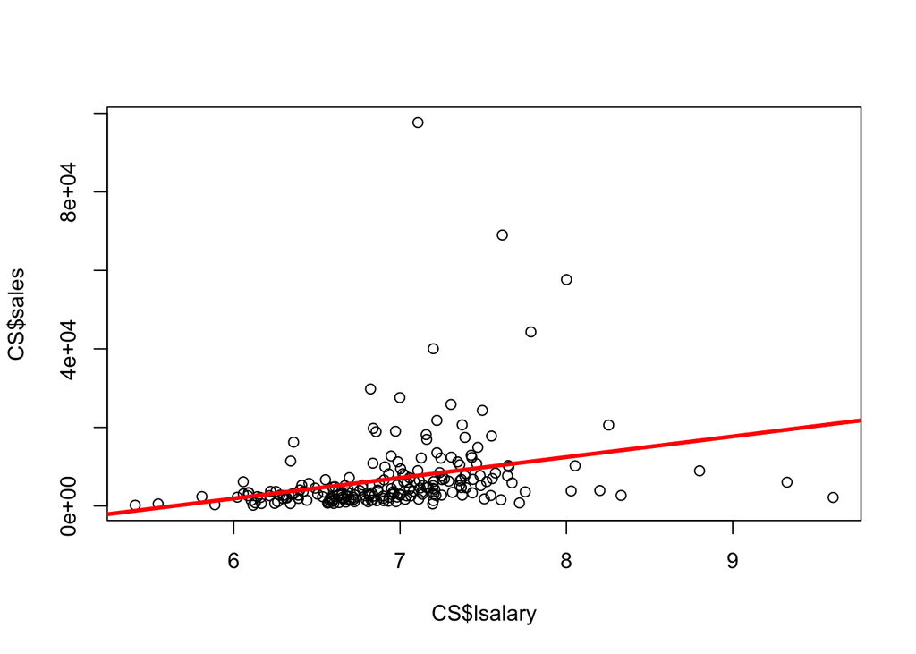

```r
#Using baseR
model1.1 <- lm(CS$sales ~ CS$lsalary)
plot(x=CS$lsalary, y=CS$sales)
abline(model1.1, col = "red", lwd=3)
```

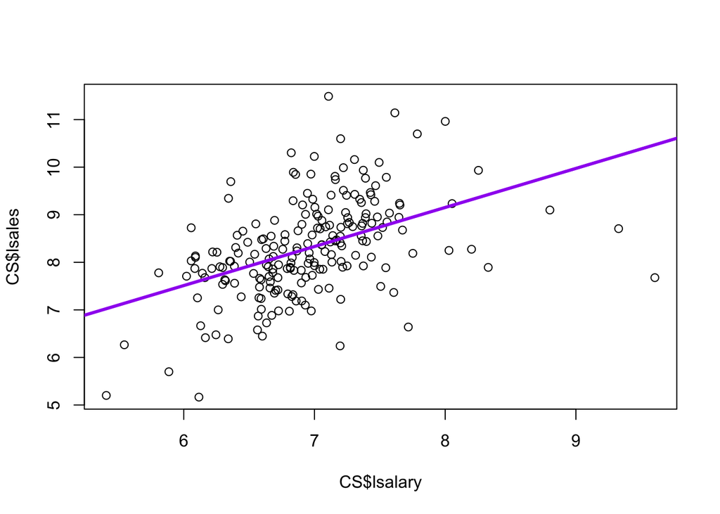

```r
#To plot regression line : abline(lm of regression, color, line width)

model1.2 <- lm(CS$lsales~CS$lsalary)
plot(x = CS$lsalary, y = CS$lsales)
abline(model1.2, col="purple",lwd=3)
```

From the scatterplots, `lsales` against `lsalary` shows more linear relationship.

#### We would like to examine how company performance (such as `roe` and `ros`) relates to CEO salaries.

- 1. Run a linear regression model of lsalary ~ roe + ros. Write out the fitted line. What percentage of the variance for lsalary is being explained by `roe` and `ros`? (3 marks)
- 2. We were told that firm sales should also affect CEO’s salaries. To include firm sales as an explanatory variable for `lsalary`, explain which variable (`sales` or `lsales`) would you include in the linear regression model. Is this model statistically (with the firm sales variable you have chosen) better at predicting `lsalary` than the model (in b(i)) without the firm sales variable? (5 marks)

(i)

```r
model2<-lm(lsalary ~ roe + ros, data = CS)
summary(model2)
```

```
##
## Call:
## lm(formula = lsalary ~ roe + ros, data = CS)
##
## Residuals:
##      Min       1Q   Median       3Q      Max
## -1.36190 -0.35383 -0.03814  0.30534  2.56389
##
## Coefficients:
##              Estimate Std. Error t value Pr(>|t|)
## (Intercept)  6.740606   0.087126  77.366  < 2e-16 ***
## roe          0.016470   0.004666   3.530 0.000512 ***
## ros         -0.001185   0.000583  -2.033 0.043325 *
## ---
## Signif. codes:  0 '***' 0.001 '**' 0.01 '*' 0.05 '.' 0.1 ' ' 1
##
## Residual standard error: 0.5511 on 206 degrees of freedom
## Multiple R-squared:  0.06229,    Adjusted R-squared:  0.05318
## F-statistic: 6.842 on 2 and 206 DF,  p-value: 0.001328
```

(ii)

lsales should be included in the model given that the plot between lsales and lsalary is more linear than sales and lsalary.

```r
model3 <- lm(lsalary ~ lsales + roe + ros, data = CS)
summary(model3)
```

```
##
## Call:
## lm(formula = lsalary ~ lsales + roe + ros, data = CS)
##
## Residuals:
##      Min       1Q   Median       3Q      Max
## -0.96060 -0.27144 -0.03264  0.22563  2.79805
##
## Coefficients:
##              Estimate Std. Error t value Pr(>|t|)
## (Intercept) 4.3117125  0.3154329  13.669  < 2e-16 ***
## lsales      0.2803149  0.0353200   7.936 1.34e-13 ***
## roe         0.0174168  0.0040923   4.256 3.17e-05 ***
## ros         0.0002417  0.0005418   0.446    0.656
## ---
## Signif. codes:  0 '***' 0.001 '**' 0.01 '*' 0.05 '.' 0.1 ' ' 1
##
## Residual standard error: 0.4832 on 205 degrees of freedom
## Multiple R-squared:  0.2827, Adjusted R-squared:  0.2722
## F-statistic: 26.93 on 3 and 205 DF,  p-value: 1.001e-14
```

```r
anova(model2,model3)
```

```
## Analysis of Variance Table
##
## Model 1: lsalary ~ roe + ros
## Model 2: lsalary ~ lsales + roe + ros
##   Res.Df    RSS Df Sum of Sq      F    Pr(>F)
## 1    206 62.566
## 2    205 47.861  1    14.705 62.987 1.338e-13 ***
## ---
## Signif. codes:  0 '***' 0.001 '**' 0.01 '*' 0.05 '.' 0.1 ' ' 1
```

From the ANOVA results, we see that there is a significant difference between the 2 linear regression models (with and without lsales) with F-statistics of 62.99 and p < 0.001.  
Hence we can conclude that the model with lsales is statistically better at predicting lsalary than the model without lsales.

## Question 3: Investment Allocation (total 10 marks)

#### Michael received $12,000 as his year-end bonus and would like to invest it. There are three types of funds that he would like to invest in. The government bond fund has a 2.75% return, the bank’s fixed deposit (FDs) has a 1.5% return, and the equity fund which has a projected return of 12%. Given his risk profile, he should not allocate more than 30% (in $ value) in the equity fund and he should invest at least three times as much in the government bonds as the FDs. Assuming the year-end yields are as projected, provide Michael with advice on how he should invest his money.

#### (a) Write down your decision variables, the objective function, and ALL constraints that apply for this optimization problem in a table. (3 marks)

Let G be the dollar investment in government bonds, F be the dollar investment in fixed deposits and E be the dollar investment in equity funds.

| Maximize total expected returns usign decision variables G, F, E | Returns = 0.0275G + 0.015F + 0.12E |
| --- | --- |
| Subject to |  |
| Budget Constraint | G + F + E $\leq$ 12000 |
| Allocation Constraint 1 | $\quad$ + $\quad$ + E $\leq$ 3600 |
| Allocation Constraint 2 | G - 3F + $\quad$ $\geq$ 0 |
| Non-Negativity Constraint 1 | G + $\quad$ + $\quad$ $\geq$ 0 |
| Non-Negativity Constraint 2 | $\quad$ + F + $\quad$ $\geq$ 0 |
| Non-Negativity Constraint 3 | $\quad$ + $\quad$ + E $\geq$ 0 |

Solve this optimization problem in R. What is the optimal dollar investment for the different investment funds? Assuming the year-end yields are as expected, how much can Michael expect to gain from his investment after one year? (3 marks)

```r
 #Defining parameters
objective.fn <- c(0.0275, 0.015, 0.12)
const.max <- matrix(c(1, 1, 1,
                      0, 0, 1,
                      1, -3, 0),
                    ncol = 3,
                    byrow = TRUE)
const.dir <- c("<=","<=",">=")
const.rhs <- c(12000, 3600, 0)

#Solving model
lp.solution <- lp("max", objective.fn, const.max, const.dir, const.rhs, compute.sens = TRUE)
#Decision variables values
lp.solution$solution
```

```
## [1] 8400    0 3600
```

```r
lp.solution
```

```
## Success: the objective function is 663
```

The optimal investment would be to invest $8400 in government bonds, $0 in fixed deposits, and $3600 in equity funds.  
He can expect to gain $663 from this investment.

#### (b) Michael was given an additional $2000 for his Long Service award and he would like to also invest this money. Given this, how much should he invest in for each of the 3 funds? (2 marks)

| Maximize total expected returns usign decision variables G, F, E | Returns = 0.0275G + 0.015F + 0.12E |
| --- | --- |
| Subject to |  |
| Budget Constraint | G + F + E $\leq$ 14000 |
| Allocation Constraint 1 | $\quad$+$\quad$+ E $\leq$ 4200 |
| Allocation Constraint 2 | G - 3F +$\quad$ $\geq$ 0 |
| Non-Negativity Constraint 1 | G +$\quad$+$\quad$ $\geq$ 0 |
| Non-Negativity Constraint 2 | $\quad$+ F +$\quad$ $\geq$ 0 |
| Non-Negativity Constraint 3 | $\quad$+$\quad$+ E $\geq$ 0 |

```r
 #Defining parameters
objective.fn <- c(0.0275, 0.015, 0.12)
const.max <- matrix(c(1, 1, 1,
                      0, 0, 1,
                      1, -3, 0),
                    ncol = 3,
                    byrow = TRUE)
const.dir <- c("<=","<=",">=")
const.rhs <- c(14000, 4200, 0)

#Solving model
lp.solution <- lp("max", objective.fn, const.max, const.dir, const.rhs, compute.sens = TRUE)
#Decision variables values
lp.solution$solution
```

```
## [1] 9800    0 4200
```

```r
lp.solution
```

```
## Success: the objective function is 773.5
```

The optimal investment would be to invest $9800 in government bonds, $0 in fixed deposits, and $4200 in equity funds.  
He can expect to gain $773.5 from this investment.

#### (c) Michael would like additional advice on how much would the returns on the fixed deposit fund have to be, minimally, to make it worth investing in. (2 marks)

```r
lp.solution$sens.coef.from
```

```
## [1]  1.50e-02 -1.00e+30  2.75e-02
```

```r
lp.solution$sens.coef.to
```

```
## [1] 1.20e-01 2.75e-02 1.00e+30
```

The returns on the fixed deposit fund have to be, minimally 2.76% to make it worth investing.